# Portfolio Analysis with R

Daryn Ramsden

Last updated: 2019-12-23

I recently came across [*Reproducible Finance with R*](https://resources.rstudio.com/webinars/reproducible-finance-with-r-jonathan-regenstein) an [RStudio Webinar](https://resources.rstudio.com/webinars) conducted by [Jonathan Regenstein](https://twitter.com/jkregenstein).

Regenstein is the author of a [book of the same title](https://www.crcpress.com/Reproducible-Finance-with-R-Code-Flows-and-Shiny-Apps-for-Portfolio-Analysis/Jr/p/book/9781138484030) and the webinar is a walkthrough of some common tasks in portfolio analysis.

In the webinar, each task is done in three different ways to illustrate three common paradigms used by R practitioners. I decided to reproduce the tasks using one approach in particular: what Regenstein refers to as the *xts* approach (based on a key R package, `xts`).

## R packages used

The code in this notebook utilizes functions in 9 packages.

- **xts ecosystem packages**
  - `PerformanceAnalytics`: Econometric tools for performance and risk analysis
  - `quantmod`: Quantitative Financial Modelling Framework
  - `xts`: Extensible time series class and methods, extending and behaving like zoo.
  - `zoo`: infrastructure for regular and irregular time series. (This a requirement for all of the other packages listed above.)
- **packages used for data visualization**
  - `ggplot2`: data viz package for R
  - `highcharter`: an htmlwidget interface to the *Highcharts* JavaScript charting library
- **other packages**
  - `purrr`: for `map` and `reduce` functions
  - `tidyr`: for `gather` function to reshape data
  - `dplyr`: for `filter` function to subset data

All of these packages can be loaded by running the following code:

```r
library(PerformanceAnalytics)
library(quantmod)
library(xts)
library(ggplot2)
library(highcharter)
library(purrr)
library(tidyr)
library(dplyr)
```

## Choosing a portfolio

In the webinar, a portfolio of ETFs was used. I used a portfolio of 9 names which I more or less chose off the top of my head (with the exception of *SPY* which was one of the tickers used in the webinar portfolio.)

- AAPL: Apple Inc.
- DIS: Walt Disney Co
- GE: General Electric Company
- JNJ: Johnson & Johnson
- KO: Coca-Cola Co
- MSFT: Microsoft Corporation
- SBUX: Starbucks Corporation
- SPY: SPDR S&P 500 ETF Trust
- TGT: Target Corporation

## Getting the data (from Yahoo Finance)

To get the historical data for my portfolio, I copied the webinar code verbatim, altering only the list of symbols to correspond to my own portfolio:

```r
symbols <- c("AAPL", "DIS", "GE", "JNJ", "KO", "MSFT", "SBUX", "SPY", "TGT")
pr_daily <- getSymbols(symbols, src = "yahoo",
           from = "2007-12-31",
           to = "2019-10-31",
           auto.assign = TRUE) %>%
  map(~Ad(get(.))) %>%
  reduce(merge)
```

To see what the created object looks like we can look at the first few rows:

```r
head(pr_daily)
```

```
##            AAPL.Adjusted DIS.Adjusted GE.Adjusted JNJ.Adjusted KO.Adjusted
## 2007-12-31      24.62137     27.38579    23.23745     46.40910    18.45844
## 2008-01-02      24.21864     27.01251    23.04312     45.85943    18.37422
## 2008-01-03      24.22982     26.95312    23.06820     45.87334    18.56672
## 2008-01-04      22.38023     26.41015    22.59179     45.81072    18.60280
## 2008-01-07      22.08067     26.43560    22.67955     46.52042    19.04194
## 2008-01-08      21.28640     25.90961    22.19060     46.57608    19.12015
##            MSFT.Adjusted SBUX.Adjusted SPY.Adjusted TGT.Adjusted
## 2007-12-31      26.88259      8.731074     114.8120     36.60070
## 2008-01-02      26.59564      8.236301     113.8069     36.24203
## 2008-01-03      26.70892      7.976115     113.7520     36.28595
## 2008-01-04      25.96133      7.724463     110.9643     35.19525
## 2008-01-07      26.13501      7.839626     110.8701     35.86139
## 2008-01-08      25.25906      8.470892     109.0797     35.83211
```

### Breaking down the code above

The chain of calls above was not trivial, especially as I had not used any of the `quantmod` functions before. So I’ll break it up into steps to make sure I(we) understand what each step is doing.

The code makes the following calls – taking the output from each as the input to the following:

1. `getSymbols`: to get price data from Yahoo Finance
2. `map`: to apply the function `Ad` on multiple items
3. `reduce`: to combine results

So it is equivalent to the following:

```r
symbols <- getSymbols(symbols, src = "yahoo",
           from = "2007-12-31",
           to = "2019-10-31",
           auto.assign = TRUE)
int_data <- map(symbols, ~Ad(get(.)))
final_data <- reduce(int_data, merge)
```

I’ll run each line of code on its own. First the call to `getSymbols`:

```r
symbols <- getSymbols(symbols, src = "yahoo",
           from = "2007-12-31",
           to = "2019-10-31",
           auto.assign = TRUE)
```

Upon running, this function I can confirm that `getSymbols` is primarily run for its side-effects: the vector `symbols` contains simply the tickers in the portfolio but the environment now has data objects corresponding to each name in the portfolio.

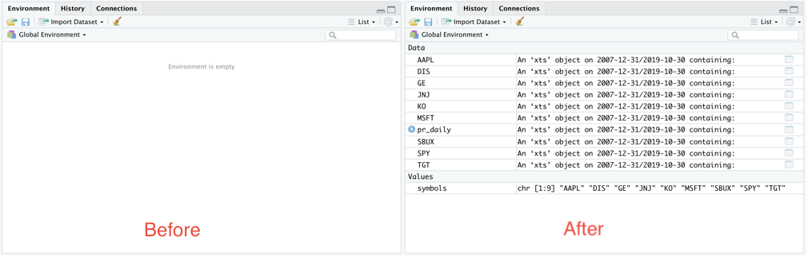

Environment compared before and after the call to getSymbols function

Picking the first of these newly-created objects (in alphabetical order) we can see what they look like:

```r
head(AAPL)
```

```
##            AAPL.Open AAPL.High AAPL.Low AAPL.Close AAPL.Volume AAPL.Adjusted
## 2007-12-31  28.50000  28.64286 28.25000   28.29714   134833300      24.62137
## 2008-01-02  28.46714  28.60857 27.50714   27.83429   269794700      24.21864
## 2008-01-03  27.91571  28.19857 27.52714   27.84714   210516600      24.22982
## 2008-01-04  27.35000  27.57143 25.55571   25.72143   363958000      22.38023
## 2008-01-07  25.89286  26.22857 24.31857   25.37714   518048300      22.08067
## 2008-01-08  25.73428  26.06571 24.40000   24.46429   380954000      21.28640
```

Each row contains a summary of the prices recorded during the corresponding day.

Next to run the call to `map{purrr}`. The intermediate data object created, `int_data` is a list of 9 xts objects.

So we can see that this call isolates the Adjusted column for each name from the larger object that contains more fields.

```r
int_data <- map(symbols, ~Ad(get(.)))
head(int_data[[1]])
```

```
##            AAPL.Adjusted
## 2007-12-31      24.62137
## 2008-01-02      24.21864
## 2008-01-03      24.22982
## 2008-01-04      22.38023
## 2008-01-07      22.08067
## 2008-01-08      21.28640
```

```r
final_data <- reduce(int_data, merge)
head(final_data)
```

```
##            AAPL.Adjusted DIS.Adjusted GE.Adjusted JNJ.Adjusted KO.Adjusted
## 2007-12-31      24.62137     27.38579    23.21641     46.40910    18.45844
## 2008-01-02      24.21864     27.01251    23.02225     45.85943    18.37422
## 2008-01-03      24.22982     26.95312    23.04730     45.87334    18.56672
## 2008-01-04      22.38023     26.41015    22.57133     45.81072    18.60280
## 2008-01-07      22.08067     26.43560    22.65901     46.52042    19.04194
## 2008-01-08      21.28640     25.90961    22.17050     46.57608    19.12015
##            MSFT.Adjusted SBUX.Adjusted SPY.Adjusted TGT.Adjusted
## 2007-12-31      26.88259      8.731074     114.2503     36.60070
## 2008-01-02      26.59564      8.236301     113.2501     36.24203
## 2008-01-03      26.70892      7.976115     113.1954     36.28595
## 2008-01-04      25.96133      7.724463     110.4214     35.19525
## 2008-01-07      26.13501      7.839626     110.3276     35.86139
## 2008-01-08      25.25906      8.470892     108.5460     35.83211
```

Next we rename the fields so they can be a little neater.

```r
names(pr_daily) <- symbols
head(pr_daily)
```

```
##                AAPL      DIS       GE      JNJ       KO     MSFT     SBUX
## 2007-12-31 24.62137 27.38579 23.23745 46.40910 18.45844 26.88259 8.731074
## 2008-01-02 24.21864 27.01251 23.04312 45.85943 18.37422 26.59564 8.236301
## 2008-01-03 24.22982 26.95312 23.06820 45.87334 18.56672 26.70892 7.976115
## 2008-01-04 22.38023 26.41015 22.59179 45.81072 18.60280 25.96133 7.724463
## 2008-01-07 22.08067 26.43560 22.67955 46.52042 19.04194 26.13501 7.839626
## 2008-01-08 21.28640 25.90961 22.19060 46.57608 19.12015 25.25906 8.470892
##                 SPY      TGT
## 2007-12-31 114.8120 36.60070
## 2008-01-02 113.8069 36.24203
## 2008-01-03 113.7520 36.28595
## 2008-01-04 110.9643 35.19525
## 2008-01-07 110.8701 35.86139
## 2008-01-08 109.0797 35.83211
```

## Getting monthly returns

Computing monthly returns consists of two steps:

- filtering the data down to the last day of each month
- calculating the month-on-month returns

### Filtering the data

The first step in getting monthly returns is to filter the data down to the last entries of each month. To do this `to.monthly {xts}` is used:

```r
pr_monthly <- to.monthly(pr_daily, indexAt = "lastof", OHLC = FALSE)
head(pr_monthly)
```

```
##                AAPL      DIS       GE      JNJ       KO     MSFT     SBUX
## 2007-12-31 24.62137 27.38579 23.23745 46.40910 18.45844 26.88259 8.731074
## 2008-01-31 16.82527 25.31574 22.16553 43.93209 17.74561 24.61720 8.065688
## 2008-02-29 15.54000 27.49608 20.97069 43.39700 17.58319 20.61932 7.669013
## 2008-03-31 17.83707 26.62225 23.41959 45.43519 18.54504 21.51384 7.464281
## 2008-04-30 21.62201 27.51305 20.69226 46.99009 17.93571 21.61996 6.922585
## 2008-05-31 23.46165 28.50566 19.43933 47.07439 17.44520 21.54738 7.758586
##                 SPY      TGT
## 2007-12-31 114.8120 36.60070
## 2008-01-31 107.8704 40.56824
## 2008-02-29 105.0827 38.61299
## 2008-03-31 104.1431 37.19647
## 2008-04-30 109.1068 38.99464
## 2008-05-31 110.7561 39.26322
```

### Calculating returns

`Return.calculate {PerformanceAnalytics}` is then used to calculate the log returns. (The call to `na.omit` has the effect of removing the first row of the data which has no entry for monthly returns)

```r
rt_monthly <- na.omit(Return.calculate(pr_monthly, method = "log"))
head(rt_monthly)
```

```
##                   AAPL         DIS          GE          JNJ           KO
## 2008-01-31 -0.38073308 -0.07859813 -0.04722700 -0.054850570 -0.039383568
## 2008-02-29 -0.07946428  0.08261746 -0.05541268 -0.012254672 -0.009194718
## 2008-03-31  0.13786158 -0.03229641  0.11044703  0.045896576  0.053259314
## 2008-04-30  0.19243293  0.03291340 -0.12381301  0.033649748 -0.033408499
## 2008-05-31  0.08165538  0.03544198 -0.06246118  0.001792409 -0.027729208
## 2008-06-30 -0.11979830 -0.07410785 -0.12913038 -0.036622732 -0.083555378
##                    MSFT        SBUX          SPY         TGT
## 2008-01-31 -0.088033395 -0.07926937 -0.062366155  0.10291805
## 2008-02-29 -0.177217104 -0.05043109 -0.026182170 -0.04939654
## 2008-03-31  0.042467953 -0.02705881 -0.008982528 -0.03737496
## 2008-04-30  0.004920375 -0.07533986  0.046561313  0.04721039
## 2008-05-31 -0.003362546  0.11401085  0.015003273  0.00686395
## 2008-06-30 -0.029018715 -0.14466672 -0.087275742 -0.13782425
```

### Adding portfolio weights

I made a choice to give each name in the portfolio equal weight whenever the portfolio is being rebalanced. So first, we create a vector of weights and then use `Return.portfolio {PerformanceAnalytics}` to get the monthly returns for the rebalanced portfolio.

```r
pw <- rep(1/9, 9)

rt_rebal_mo <- Return.portfolio(rt_monthly, weights = pw,
                                    rebalance_on = "months")
```

This creates an xts object of portfolio returns for a portfolio rebalanced monthly:

```r
head(rt_rebal_mo)
```

```
##            portfolio.returns
## 2008-01-31       -0.08083813
## 2008-02-29       -0.04188176
## 2008-03-31        0.03157997
## 2008-04-30        0.01390298
## 2008-05-31        0.01791277
## 2008-06-30       -0.09355556
```

#### The date is a row index. And not contained in a column of the data.

Just taking a pause to note that the date is the row index, an essential ingredient of an xts object. (This was pointed out in the webinar.)

```r
head(index(rt_rebal_mo))
```

```
## [1] "2008-01-31" "2008-02-29" "2008-03-31" "2008-04-30" "2008-05-31"
## [6] "2008-06-30"
```

## Ok, now for some useful calculations

Next we use some of the functions provided by the `PerformanceAnalytics` package to calculate common summary statistics for the portfolio.

### Standard Deviation of returns

We can get the standard deviation of the returns using `StdDev {PerformanceAnalytics}`.

```r
sd_rt <- StdDev(rt_rebal_mo)
sd_rt
```

```
##              [,1]
## StdDev 0.04576782
```

I notice that this appears to be a **matrix** object. So I checked:

```r
class(sd_rt)
```

```
## [1] "matrix"
```

### Table of Downside Risks

Another useful function is `table.DownsideRisk {PerformanceAnalytics}`, which compiles 11 different risk metrics.

```r
table.DownsideRisk(rt_rebal_mo)
```

```
##                              portfolio.returns
## Semi Deviation                          0.0345
## Gain Deviation                          0.0269
## Loss Deviation                          0.0350
## Downside Deviation (MAR=10%)            0.0343
## Downside Deviation (Rf=0%)              0.0304
## Downside Deviation (0%)                 0.0304
## Maximum Drawdown                        0.5219
## Historical VaR (95%)                   -0.0747
## Historical ES (95%)                    -0.1019
## Modified VaR (95%)                     -0.0719
## Modified ES (95%)                      -0.1101
```

### Table of Drawdowns

We can also get a summary of the worst drawdowns in the time period we have data for, using `table.Drawdowns {PerformanceAnalytics}`:

```r
table.Drawdowns(rt_rebal_mo)
```

```
##         From     Trough         To   Depth Length To Trough Recovery
## 1 2008-01-31 2009-02-28 2011-02-28 -0.5219     38        14       24
## 2 2018-10-31 2018-12-31 2019-04-30 -0.1329      7         3        4
## 3 2011-08-31 2011-09-30 2011-12-31 -0.0822      5         2        3
## 4 2014-01-31 2014-01-31 2014-04-30 -0.0699      4         1        3
## 5 2015-08-31 2015-08-31 2015-10-31 -0.0677      3         1        2
```

### SemiDeviation

One of the measures included in the table of Downside risks above was the SemiDeviation, the standard deviation of returns below the mean. This summary statistic can be returned as a standalone value using the `SemiDeviation {PerformanceAnalytics}` function.

```r
SemiDeviation(rt_rebal_mo)
```

```
##                portfolio.returns
## Semi-Deviation        0.03446606
```

### Sharpe ratio

Another common measure is the [Sharpe ratio](https://en.wikipedia.org/wiki/Sharpe_ratio), which measures the return per unit of risk. For this we use the `SharpeRatio {PerformanceAnalytics}` function.

```r
SharpeRatio(rt_rebal_mo)
```

```
##                               portfolio.returns
## StdDev Sharpe (Rf=0%, p=95%):        0.18983084
## VaR Sharpe (Rf=0%, p=95%):           0.12080936
## ES Sharpe (Rf=0%, p=95%):            0.07887682
```

### Returns summary

A general summary of returns can be obtained using `table.Stats {PerformanceAnalytics}`

```r
table.Stats(rt_rebal_mo)
```

```
##                 portfolio.returns
## Observations             142.0000
## NAs                        0.0000
## Minimum                   -0.1645
## Quartile 1                -0.0117
## Median                     0.0136
## Arithmetic Mean            0.0087
## Geometric Mean             0.0076
## Quartile 3                 0.0343
## Maximum                    0.1338
## SE Mean                    0.0038
## LCL Mean (0.95)            0.0011
## UCL Mean (0.95)            0.0163
## Variance                   0.0021
## Stdev                      0.0458
## Skewness                  -0.5582
## Kurtosis                   1.5000
```

## Visualizing portfolio performance

Next, the webinar moved into visualizing the performance of the portfolio. This was done using both `ggplot2` and `highcharter`. I reproduced both and inserted an extra `ggplot2` chart of my own.

### Combining all returns into one object

The first step we take on the way to visualizing the portfolio’s returns is to create a single xts object with the monthly returns of the portfolio (rebalanced monthly) in addition to the returns corresponding to each of the individual tickers. This makes use of`merge.xts {xts}`.

```r
rt_rebal_mo <- merge.xts(rt_rebal_mo, rt_monthly)
df <- data.frame(rt_rebal_mo, date = index(rt_rebal_mo))
head(df)
```

```
##            portfolio.returns        AAPL         DIS          GE          JNJ
## 2008-01-31       -0.08083813 -0.38073308 -0.07859813 -0.04722700 -0.054850570
## 2008-02-29       -0.04188176 -0.07946428  0.08261746 -0.05541268 -0.012254672
## 2008-03-31        0.03157997  0.13786158 -0.03229641  0.11044703  0.045896576
## 2008-04-30        0.01390298  0.19243293  0.03291340 -0.12381301  0.033649748
## 2008-05-31        0.01791277  0.08165538  0.03544198 -0.06246118  0.001792409
## 2008-06-30       -0.09355556 -0.11979830 -0.07410785 -0.12913038 -0.036622732
##                      KO         MSFT        SBUX          SPY         TGT
## 2008-01-31 -0.039383568 -0.088033395 -0.07926937 -0.062366155  0.10291805
## 2008-02-29 -0.009194718 -0.177217104 -0.05043109 -0.026182170 -0.04939654
## 2008-03-31  0.053259314  0.042467953 -0.02705881 -0.008982528 -0.03737496
## 2008-04-30 -0.033408499  0.004920375 -0.07533986  0.046561313  0.04721039
## 2008-05-31 -0.027729208 -0.003362546  0.11401085  0.015003273  0.00686395
## 2008-06-30 -0.083555378 -0.029018715 -0.14466672 -0.087275742 -0.13782425
##                  date
## 2008-01-31 2008-01-31
## 2008-02-29 2008-02-29
## 2008-03-31 2008-03-31
## 2008-04-30 2008-04-30
## 2008-05-31 2008-05-31
## 2008-06-30 2008-06-30
```

### Plotting portfolio returns

`ggplot {ggplot2}` can be used to make a line chart of the entire portfolio’s returns over the time period of analysis.

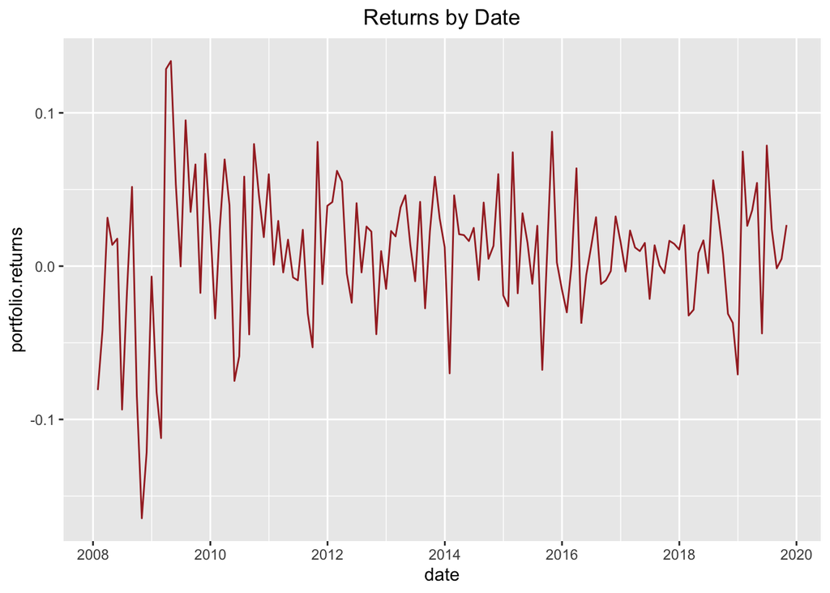

```r
ggplot(data = df, aes(x = date, y = portfolio.returns)) +
  geom_line(colour = "brown") +
  scale_x_date(breaks = scales::pretty_breaks(n = 6)) +
  ggtitle("Returns by Date") +
  theme(plot.title = element_text(hjust = 0.5))
```

### Visualizing each component compared to the portfolio

Next, I decided to try to plot the returns of each portfolio component in contrast to the aggregate returns. To do this I first reshaped the data using `gather {tidyr}` to get it into a good format for using `ggplot {ggplot2}` later on. (After the reshaping, I output one line per ticker to illustrate the format of the new data frame.)

```r
df_narrow <- gather(df, key = "Component", value = "Return", -date)
df_narrow[c(1, 143, 285, 427, 569, 711, 853, 995, 1137, 1279),]
```

```
##            date         Component      Return
## 1    2008-01-31 portfolio.returns -0.08083813
## 143  2008-01-31              AAPL -0.38073308
## 285  2008-01-31               DIS -0.07859813
## 427  2008-01-31                GE -0.04722700
## 569  2008-01-31               JNJ -0.05485057
## 711  2008-01-31                KO -0.03938357
## 853  2008-01-31              MSFT -0.08803339
## 995  2008-01-31              SBUX -0.07926937
## 1137 2008-01-31               SPY -0.06236615
## 1279 2008-01-31               TGT  0.10291805
```

Now that the data has been reshaped, I can plot the returns by portfolio component with the aggregate returns as contrast for each component.

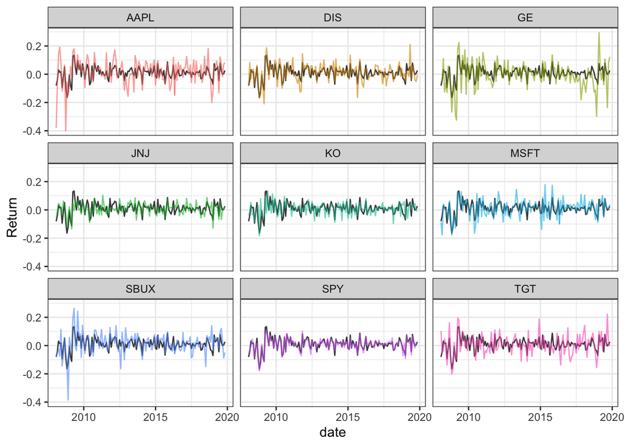

```r
bg_df <- filter(df_narrow, Component == "portfolio.returns") %>%
  select(-Component)
ggplot(data = filter(df_narrow, Component != "portfolio.returns")) +
  geom_line(data = bg_df, aes(x = date, y = Return), colour = "#484848") +
  geom_line(alpha = 0.6, aes(x = date, y = Return, group = Component, colour = Component)) +
  facet_wrap(~Component) + theme_bw() +
  theme(legend.position = "none")
```

I guess it makes sense that **SPY** would the name that matches the overall portfolio volatility most closely.

## Using highcharter

I was unacquainted with the `highcharter` package (and the *Highcharts* JavaScript library that it interfaces with) and I was impressed by the interactive chart/application created by a single function call. I simply copied the webinar code verbatim and ran it. And it worked.

### Computing rolling standard deviations.

As a preliminary to creating the application, we use the `rollapply {zoo}` function to calculate the rolling 24-month standard deviation of returns of the portfolio:

```r
window <- 24

pr_rolling_sd_24 <- rollapply(rt_rebal_mo, FUN = sd,
          width = window) %>%
  na.omit()

head(pr_rolling_sd_24)
```

```
##            portfolio.returns      AAPL        DIS        GE        JNJ
## 2009-12-31        0.08020549 0.1521761 0.09532935 0.1478035 0.05427647
## 2010-01-31        0.07881217 0.1304394 0.09566684 0.1489913 0.05325709
## 2010-02-28        0.07850901 0.1292145 0.09481646 0.1490277 0.05318419
## 2010-03-31        0.07953504 0.1292370 0.09720802 0.1496388 0.05283245
## 2010-04-30        0.07987657 0.1253638 0.09755685 0.1486095 0.05251636
## 2010-05-31        0.08137736 0.1247572 0.09958678 0.1505326 0.05561328
##                    KO       MSFT      SBUX        SPY       TGT
## 2009-12-31 0.06890433 0.08623897 0.1377572 0.06960654 0.1042185
## 2010-01-31 0.06919825 0.08585820 0.1372322 0.06895675 0.1026855
## 2010-02-28 0.06944485 0.07765557 0.1369721 0.06929306 0.1022012
## 2010-03-31 0.06963195 0.07731957 0.1370647 0.07054546 0.1019549
## 2010-04-30 0.06953472 0.07772306 0.1362073 0.06987456 0.1027298
## 2010-05-31 0.06978016 0.08502770 0.1347769 0.07152529 0.1031023
```

Next, I created the HighChart plot. Again using the code from the webinar (but I make one tiny exception to turn the legend off.)

```r
highchart(type = "stock") %>%
  hc_title(text = "24-Month Rolling volatility") %>%
  hc_add_series(pr_rolling_sd_24) %>%
  hc_add_theme(hc_theme_flat()) %>%
  hc_yAxis(
    labels = list(format = "{value}%"),
    opposite = FALSE) %>%
  hc_navigator(enabled = FALSE) %>%
  hc_scrollbar(enabled = FALSE) %>%
  hc_exporting(enabled = TRUE) %>%
  hc_legend(enabled = FALSE)
```

[interactive chart not shown]

I really like this chart and it makes me think that I need to learn more about the Highcharts JavaScript library.

Anyhow, that’s it: the entire walkthrough of the webinar tasks using the xts ecosystem. In the webinar, each of these tasks is also done in two alternative ways: using what he described as *tidyverse* and *tidyquant* approaches respectively. I decided to focus on the xts approach because it seemed like the cleanest for the problem at hand.